# R Notebook

# Begin by loading the appropriate libraries and the dataset

```r
library(pacman)
p_load(tidyverse, psych, haven, polycor, caret, car, MASS)
cambridge <- read_sav("data/Cambridge_delinquency_with_caseid.sav")
```

# Question 1: Creating a dataset

## My slight previous knowledge of delinquency would initially lead me to want to consider variables such as gender, ethnicity, and SES as covariates. However, the background literature provided notes that this all-boy sample is overwhelmingly white and of a similar socioeconomic status. Low variability in the data will hinder analysis of differences, and so descriptive statistics will be used to test variance and assess the usability of the variables

## The literature also notes that data were collected from multiple sources - parents, teachers, peers, and the individuals themselves. I will use data collected from each source, so that information can be triangulated for a stronger analysis.

## I also note that the authors listed on page 22 factors that they found to be predictors of criminality - these will be included in the dataset that I create.

## Additionally, the model the authors eventually create included inhibiting factors such as consicience, empathy, and skills - these will be included in dataset I create.

## Given the goal listed in question 3 of early predictors of criminality, I will include variables listed at the first time point only as predictors (when the boys were aged 8 - 10). I will collapse criminality into two variables - a binary that includes whether or not an individual was ever convicted, and a listing of the total number of convictions

## I first want to get a brief glimpse of the dataset

```r
head(cambridge)
```

| v1 | v4 | v12 | v13 | v14 | v15 | v16 | v17 | v18 | v19 | v20 | v21 | v22 | v23 | v24 | v25 | v26 | v27 | v28 | v29 | v30 | v31 | v32 | v33 | v34 | v35 | v36 | v37 | v38 | v39 | … |
| --- | --- | --- | --- | --- | --- | --- | --- | --- | --- | --- | --- | --- | --- | --- | --- | --- | --- | --- | --- | --- | --- | --- | --- | --- | --- | --- | --- | --- | --- | --- |
| 8488 | 1 | NA | 0 | 0 | 0 | 0 | 0 | 0 | 0 | 0 | 0 | 0 | 0 | 0 | 0 | 0 | 0 | 1 | 1 | 1 | 1 | 1 | 1 | 1 | 1 | 1 | 1 | 1 | 2 | … |
| 8488 | 2 | NA | 0 | 0 | 0 | 0 | 0 | 0 | 0 | 0 | 0 | 0 | 0 | 0 | 0 | 0 | 0 | 1 | 1 | 1 | 1 | 1 | 1 | 1 | 1 | 1 | 1 | 1 | 1 | … |
| 8488 | 3 | 3 | 0 | 0 | 0 | 0 | 1 | 0 | 0 | 0 | 0 | 0 | 0 | 0 | 0 | 0 | 0 | 2 | 1 | 2 | 2 | 1 | 2 | 2 | 1 | 1 | 1 | 2 | 2 | … |
| 8488 | 4 | 3 | 0 | 0 | 0 | 0 | 1 | 0 | 0 | 0 | 1 | 0 | 0 | 0 | 0 | 0 | 0 | 2 | 2 | 3 | 4 | 1 | 2 | 2 | 2 | 1 | 2 | 3 | 3 | … |
| 8488 | 5 | 7 | 0 | 0 | 0 | 0 | 0 | 0 | 0 | 0 | 0 | 1 | 1 | 0 | 0 | 1 | 0 | 1 | 3 | 4 | 3 | 1 | 1 | 1 | 3 | 2 | 4 | 4 | 2 | … |
| 8488 | 6 | NA | 0 | 0 | 0 | 0 | 0 | 0 | 0 | 0 | 0 | 0 | 0 | 0 | 0 | 0 | 0 | 1 | 1 | 1 | 1 | 1 | 1 | 1 | 1 | 1 | 1 | 1 | 1 | … |

## I noted that there were combined conviction variables, but the seemed to be collapsed to factors instead of being numeric, so I created my own variable of the number of convictions.

```r
cambridge <- cambridge %>%
  mutate(total_convictions = (v13 + v14 + v15 + v16 + v17 + v18 + v19 + v20 + v21 + v22 + v23 + v24 + v25 + v26 + v27), na.rm = T)
```

## I then used the variable I created to create a binary variable of whether or not the participant had ever been convicted.

```r
cambridge <- cambridge %>%
  mutate(ever_convicted = ifelse(total_convictions > 0, "yes", "no"))
```

## I next created an abbreviated dataset of variables that looked like the could possible affect the likelihood and rate of convictions in the sample. Most of the variables are social, and were selected based on the criteria named above.

```r
cam.abbrev <- cambridge %>%
  dplyr::select(v4, v42, v54, v89, v91, v104, v108, v117:v119, v124, v125, v132, v134, v142, v154, v155, v158, v159, v165, v168:v171, v178, v179, total_convictions, ever_convicted)
```

## I still have quite a few variables and wanted to get at least an idea of what some of the variables looked like, and if any of them were missing so much data as to render them dubious, so I checked with the “summary” function. I excluded variables in which more than 5% of the data were missing, leaving me with a total of 16 variables.

```r
summary(cam.abbrev)
```

```
       v4             v42             v54             v89             v91
 Min.   :  1.0   Min.   :1.000   Min.   :1.000   Min.   :1.000   Min.   :1.00
 1st Qu.:103.5   1st Qu.:1.000   1st Qu.:2.000   1st Qu.:1.000   1st Qu.:1.00
 Median :206.0   Median :1.000   Median :2.000   Median :1.000   Median :2.00
 Mean   :206.0   Mean   :1.187   Mean   :2.545   Mean   :1.277   Mean   :1.61
 3rd Qu.:308.5   3rd Qu.:1.000   3rd Qu.:3.000   3rd Qu.:2.000   3rd Qu.:2.00
 Max.   :411.0   Max.   :2.000   Max.   :5.000   Max.   :2.000   Max.   :2.00
                                                 NA's   :50      NA's   :93
      v104            v108            v117            v118            v119
 Min.   :1.000   Min.   :1.000   Min.   :1.000   Min.   :1.000   Min.   :1.000
 1st Qu.:1.000   1st Qu.:1.750   1st Qu.:2.000   1st Qu.:1.000   1st Qu.:1.000
 Median :1.000   Median :2.000   Median :2.000   Median :1.000   Median :2.000
 Mean   :1.832   Mean   :1.945   Mean   :1.969   Mean   :1.524   Mean   :2.382
 3rd Qu.:2.000   3rd Qu.:2.000   3rd Qu.:2.000   3rd Qu.:1.000   3rd Qu.:3.000
 Max.   :4.000   Max.   :3.000   Max.   :3.000   Max.   :5.000   Max.   :4.000
 NA's   :29      NA's   :27      NA's   :28      NA's   :39
      v124            v125            v132            v134            v142
 Min.   :1.000   Min.   :1.000   Min.   :1.000   Min.   :1.000   Min.   :1.000
 1st Qu.:1.000   1st Qu.:2.000   1st Qu.:2.000   1st Qu.:1.000   1st Qu.:1.000
 Median :1.000   Median :3.000   Median :2.000   Median :1.000   Median :2.000
 Mean   :1.119   Mean   :2.551   Mean   :1.987   Mean   :1.192   Mean   :1.691
 3rd Qu.:1.000   3rd Qu.:4.000   3rd Qu.:2.000   3rd Qu.:1.000   3rd Qu.:2.000
 Max.   :2.000   Max.   :4.000   Max.   :3.000   Max.   :3.000   Max.   :3.000
 NA's   :40      NA's   :26      NA's   :36
      v154            v155            v158            v159            v165
 Min.   :1.000   Min.   :1.000   Min.   :1.000   Min.   :1.000   Min.   :1.000
 1st Qu.:2.000   1st Qu.:1.000   1st Qu.:1.000   1st Qu.:2.000   1st Qu.:2.000
 Median :2.000   Median :1.000   Median :2.000   Median :2.000   Median :3.000
 Mean   :2.036   Mean   :1.145   Mean   :2.484   Mean   :1.987   Mean   :3.027
 3rd Qu.:2.000   3rd Qu.:1.000   3rd Qu.:3.000   3rd Qu.:2.000   3rd Qu.:4.000
 Max.   :3.000   Max.   :2.000   Max.   :4.000   Max.   :3.000   Max.   :5.000
                 NA's   :10      NA's   :14      NA's   :29      NA's   :9
      v168           v169            v170            v171            v178
 Min.   :1.00   Min.   :1.000   Min.   :1.000   Min.   :1.000   Min.   :1.000
 1st Qu.:2.00   1st Qu.:1.000   1st Qu.:1.000   1st Qu.:1.000   1st Qu.:1.000
 Median :2.00   Median :1.000   Median :1.000   Median :2.000   Median :2.000
 Mean   :2.01   Mean   :1.337   Mean   :1.117   Mean   :1.794   Mean   :2.158
 3rd Qu.:2.00   3rd Qu.:2.000   3rd Qu.:1.000   3rd Qu.:2.000   3rd Qu.:3.000
 Max.   :3.00   Max.   :2.000   Max.   :2.000   Max.   :3.000   Max.   :4.000
 NA's   :15     NA's   :10      NA's   :9       NA's   :9       NA's   :44
      v179       total_convictions ever_convicted
 Min.   :1.000   Min.   : 0.000    Length:411
 1st Qu.:1.000   1st Qu.: 0.000    Class :character
 Median :2.000   Median : 0.000    Mode  :character
 Mean   :2.138   Mean   : 1.127
 3rd Qu.:3.000   3rd Qu.: 1.000
 Max.   :4.000   Max.   :14.000
 NA's   :28      NA's   :16
```

```r
cam.abbrev <- cam.abbrev %>%
  dplyr::select(-c(v89, v91, v104, v108, v117, v118, v124, v125, v132, v159, v178, v179))
```

## I proceeded to rename the selected variables into something that made more sense, and the for simplicity omit incomplete data:

```r
cam.abbrev <- rename(cam.abbrev, research.id = v4, acting.out = v42, conduct.disorder = v54, iq = v119, broken.home = v134, social.handicap = v142, attendance = v155, teacher.rating = v154, verbal.comp = v158, lazy = v165, apathy = v168, concentration = v169, peer.relations = v170, cleanliness = v171)
cam.abbrev <- na.omit(cam.abbrev)
```

# Question 2: Exploring the dataset

```r
cam.abbrev <- cam.abbrev %>%
  mutate_if(is.numeric,funs(as.integer(.))) %>%
  mutate(total_convictions = as.numeric(total_convictions)) %>%
  mutate(research.id = as.character(research.id)) %>%
  mutate(ever_convicted = as.factor(ever_convicted))
str(cam.abbrev)
```

```
Classes ‘tbl_df’, ‘tbl’ and 'data.frame':   364 obs. of  16 variables:
 $ research.id      : chr  "1" "2" "3" "4" ...
 $ acting.out       : int  1 1 1 1 1 1 1 1 1 1 ...
 $ conduct.disorder : int  1 2 4 2 1 2 2 2 4 3 ...
 $ iq               : int  2 3 3 4 2 4 1 1 2 1 ...
 $ broken.home      : int  1 3 2 1 1 1 3 1 1 1 ...
 $ social.handicap  : int  1 1 2 2 1 2 2 2 2 2 ...
 $ teacher.rating   : int  1 2 2 2 1 2 1 2 3 2 ...
 $ attendance       : int  1 1 1 1 1 1 1 1 1 2 ...
 $ verbal.comp      : int  1 4 2 2 1 4 1 2 4 2 ...
 $ lazy             : int  3 2 3 3 3 3 2 3 5 3 ...
 $ apathy           : int  2 2 2 2 2 2 1 2 3 2 ...
 $ concentration    : int  1 1 1 1 1 1 1 1 1 1 ...
 $ peer.relations   : int  1 2 1 1 1 1 2 1 1 1 ...
 $ cleanliness      : int  1 2 2 2 1 2 1 2 2 1 ...
 $ total_convictions: num  0 0 1 2 0 2 4 0 1 0 ...
 $ ever_convicted   : Factor w/ 2 levels "no","yes": 1 1 2 2 1 2 2 1 2 1 ...
```

## Descriptives show that only about a third of the participants were ever convicted. Of those convicted, the mean total convictions suggests that most were only convicted a few times, but the range suggests that at least some participants were convicted many times.

```r
describe(cam.abbrev)
```

|  | vars | n | mean | sd | median | trimmed | mad | min | max | range | skew | kurtosis | se |
| --- | --- | --- | --- | --- | --- | --- | --- | --- | --- | --- | --- | --- | --- |
| research.id* | 1 | 364 | 205.68 | 117.71 | 206.5 | 205.67 | 149.74 | 1 | 411 | 410 | 0.00 | -1.20 | 6.17 |
| acting.out | 2 | 364 | 1.19 | 0.39 | 1.0 | 1.11 | 0.00 | 1 | 2 | 1 | 1.60 | 0.56 | 0.02 |
| conduct.disorder | 3 | 364 | 2.53 | 1.14 | 2.0 | 2.45 | 1.48 | 1 | 5 | 4 | 0.55 | -0.44 | 0.06 |
| iq | 4 | 364 | 2.35 | 1.11 | 2.0 | 2.32 | 1.48 | 1 | 4 | 3 | 0.13 | -1.34 | 0.06 |
| broken.home | 5 | 364 | 1.20 | 0.56 | 1.0 | 1.03 | 0.00 | 1 | 3 | 2 | 2.66 | 5.46 | 0.03 |
| social.handicap | 6 | 364 | 1.71 | 0.70 | 2.0 | 1.64 | 1.48 | 1 | 3 | 2 | 0.46 | -0.89 | 0.04 |
| teacher.rating | 7 | 364 | 2.02 | 0.68 | 2.0 | 2.03 | 0.00 | 1 | 3 | 2 | -0.03 | -0.83 | 0.04 |
| attendance | 8 | 364 | 1.15 | 0.36 | 1.0 | 1.07 | 0.00 | 1 | 2 | 1 | 1.94 | 1.77 | 0.02 |
| verbal.comp | 9 | 364 | 2.47 | 1.11 | 2.0 | 2.46 | 1.48 | 1 | 4 | 3 | 0.03 | -1.34 | 0.06 |
| lazy | 10 | 364 | 3.03 | 1.10 | 3.0 | 3.03 | 1.48 | 1 | 5 | 4 | 0.00 | -0.54 | 0.06 |

[output cut: 6 more lines]

```r
cam.abbrev %>%
  count(ever_convicted)
```

| ever_convicted | n |
| --- | --- |
| no | 244 |
| yes | 120 |

## A histogram confirms that the data in the dependent variable are not normally distributed.

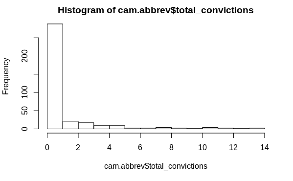

```r
hist(cam.abbrev$total_convictions)
```

## I used the hetcor function to explore pearson and polyserial relationships between the dependent variables and other factor variables. Based on these correlations, conduct disorder and social handicap should be retained for a model involving total convictions. Because IQ showed a moderate correlation with whether a person had ever been convicted, I decided to retain that variable as well.

```r
hetcor(as.data.frame(cam.abbrev[, 2:16]))
```

```
Two-Step Estimates

Correlations/Type of Correlation:
```

|  | acting.out | conduct.disorder | iq | broken.home | social.handicap | teacher.rating | attendance | verbal.comp | lazy | apathy | concentration | peer.relations | cleanliness | total_convictions | ever_convicted |
| --- | --- | --- | --- | --- | --- | --- | --- | --- | --- | --- | --- | --- | --- | --- | --- |
| acting.out | 1 | Pearson | Pearson | Pearson | Pearson | Pearson | Pearson | Pearson | Pearson | Pearson | Pearson | Pearson | Pearson | Pearson | Polyserial |
| conduct.disorder | 0.6395 | 1 | Pearson | Pearson | Pearson | Pearson | Pearson | Pearson | Pearson | Pearson | Pearson | Pearson | Pearson | Pearson | Polyserial |
| iq | 0.1714 | 0.2662 | 1 | Pearson | Pearson | Pearson | Pearson | Pearson | Pearson | Pearson | Pearson | Pearson | Pearson | Pearson | Polyserial |
| broken.home | 0.01954 | 0.07286 | 0.01548 | 1 | Pearson | Pearson | Pearson | Pearson | Pearson | Pearson | Pearson | Pearson | Pearson | Pearson | Polyserial |
| social.handicap | 0.249 | 0.3081 | 0.2646 | 0.1112 | 1 | Pearson | Pearson | Pearson | Pearson | Pearson | Pearson | Pearson | Pearson | Pearson | Polyserial |
| teacher.rating | 0.5136 | 0.7877 | 0.2745 | 0.0379 | 0.3064 | 1 | Pearson | Pearson | Pearson | Pearson | Pearson | Pearson | Pearson | Pearson | Polyserial |
| attendance | 0.2308 | 0.2152 | 0.02433 | 0.05654 | 0.1416 | 0.2452 | 1 | Pearson | Pearson | Pearson | Pearson | Pearson | Pearson | Pearson | Polyserial |
| verbal.comp | 0.1543 | 0.3101 | 0.4278 | 0.02828 | 0.2636 | 0.2924 | 0.1545 | 1 | Pearson | Pearson | Pearson | Pearson | Pearson | Pearson | Polyserial |
| lazy | 0.3994 | 0.5601 | 0.2615 | -0.01335 | 0.1973 | 0.6357 | 0.1783 | 0.2111 | 1 | Pearson | Pearson | Pearson | Pearson | Pearson | Polyserial |
| apathy | 0.3591 | 0.5277 | 0.3116 | 0.05502 | 0.321 | 0.6067 | 0.1161 | 0.3047 | 0.51 | 1 | Pearson | Pearson | Pearson | Pearson | Polyserial |

[output cut: 5 more lines]

```
Standard Errors:
```

|  | acting.out | conduct.disorder | iq | broken.home | social.handicap | teacher.rating | attendance | verbal.comp | lazy | apathy | concentration | peer.relations | cleanliness | total_convictions |
| --- | --- | --- | --- | --- | --- | --- | --- | --- | --- | --- | --- | --- | --- | --- |
| acting.out |  |  |  |  |  |  |  |  |  |  |  |  |  |  |
| conduct.disorder | 0.03107 |  |  |  |  |  |  |  |  |  |  |  |  |  |
| iq | 0.05094 | 0.04877 |  |  |  |  |  |  |  |  |  |  |  |  |
| broken.home | 0.05246 | 0.0522 | 0.05246 |  |  |  |  |  |  |  |  |  |  |  |
| social.handicap | 0.04924 | 0.04752 | 0.04882 | 0.05183 |  |  |  |  |  |  |  |  |  |  |
| teacher.rating | 0.03868 | 0.01997 | 0.04854 | 0.0524 | 0.04757 |  |  |  |  |  |  |  |  |  |
| attendance | 0.04969 | 0.05006 | 0.05245 | 0.05231 | 0.05143 | 0.04933 |  |  |  |  |  |  |  |  |
| verbal.comp | 0.05123 | 0.04745 | 0.04291 | 0.05244 | 0.04885 | 0.04801 | 0.05123 |  |  |  |  |  |  |  |
| lazy | 0.04414 | 0.03606 | 0.0489 | 0.05247 | 0.05044 | 0.03133 | 0.05082 | 0.05015 |  |  |  |  |  |  |
| apathy | 0.04574 | 0.03791 | 0.0474 | 0.05232 | 0.04709 | 0.03322 | 0.05177 | 0.04763 | 0.03888 |  |  |  |  |  |

[output cut: 5 more lines]

```
n = 364

P-values for Tests of Bivariate Normality:
```

|  | acting.out | conduct.disorder | iq | broken.home | social.handicap | teacher.rating | attendance | verbal.comp | lazy | apathy | concentration | peer.relations | cleanliness | total_convictions |
| --- | --- | --- | --- | --- | --- | --- | --- | --- | --- | --- | --- | --- | --- | --- |
| acting.out |  |  |  |  |  |  |  |  |  |  |  |  |  |  |
| conduct.disorder | 4.663e-139 |  |  |  |  |  |  |  |  |  |  |  |  |  |
| iq | 6.121e-134 | 6.755e-08 |  |  |  |  |  |  |  |  |  |  |  |  |
| broken.home | 2.171e-290 | 1.075e-156 | 1.322e-151 |  |  |  |  |  |  |  |  |  |  |  |
| social.handicap | 6.411e-193 | 1.579e-60 | 1.832e-54 | 5.757e-210 |  |  |  |  |  |  |  |  |  |  |
| teacher.rating | 1.8e-192 | 2.059e-82 | 2.434e-54 | 4.754e-208 | 1.065e-110 |  |  |  |  |  |  |  |  |  |
| attendance | 3.779e-281 | 1.021e-148 | 5.911e-143 | 3.11e-299 | 2.127e-200 | 2.175e-200 |  |  |  |  |  |  |  |  |
| verbal.comp | 2.141e-132 | 0.0001166 | 0.2263 | 3.179e-149 | 1.949e-53 | 1.194e-52 | 8.274e-142 |  |  |  |  |  |  |  |
| lazy | 1.057e-180 | 2.248e-48 | 6.125e-40 | 4.777e-195 | 6.705e-99 | 9.91e-97 | 6.297e-187 | 2.908e-39 |  |  |  |  |  |  |
| apathy | 2.15e-218 | 6.922e-90 | 2.54e-83 | 1.377e-235 | 2.982e-139 | 4.402e-138 | 7.217e-227 | 1.17e-80 | 3.72e-126 |  |  |  |  |  |

[output cut: 5 more lines]

## Additionally, boxplots show a trend of convictions increasing at higher levels of the variables of interest.

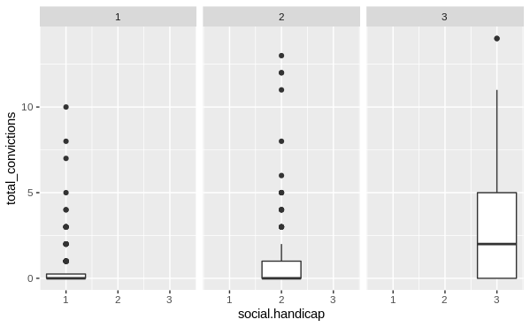

```r
ggplot(cam.abbrev, aes(social.handicap, total_convictions)) +
  geom_boxplot() +
  facet_grid(~social.handicap)
```

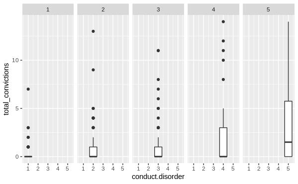

```r
ggplot(cam.abbrev, aes(conduct.disorder, total_convictions)) +
  geom_boxplot() +
  facet_grid(~conduct.disorder)
```

## For the IQ variable that showed a correlation with the binary “ever_convicted”, a bar plot suggests that individuals with higher IQ levels were less likely to be convicted of a crime.

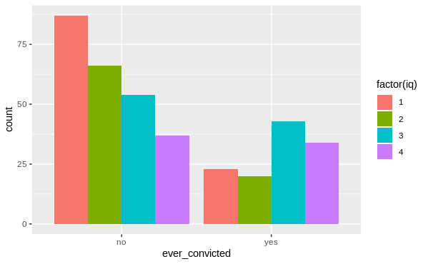

```r
ggplot(cam.abbrev) +
  geom_bar(mapping = aes(x = ever_convicted, fill = factor(iq)), position = "dodge")
```

# Question 3: Modeling

```r
model1 <- lm(total_convictions ~ social.handicap + conduct.disorder + iq, data = cam.abbrev)
summary(model1)
```

```
Call:
lm(formula = total_convictions ~ social.handicap + conduct.disorder +
    iq, data = cam.abbrev)

Residuals:
    Min      1Q  Median      3Q     Max
-3.7304 -1.2621 -0.4756  0.4901 11.4633

Coefficients:
                 Estimate Std. Error t value Pr(>|t|)
(Intercept)       -1.9927     0.3926  -5.076 6.20e-07 ***
social.handicap    0.7266     0.1823   3.985 8.17e-05 ***
conduct.disorder   0.4891     0.1120   4.366 1.65e-05 ***
iq                 0.2745     0.1134   2.422   0.0159 *
---
Signif. codes:  0 ‘***’ 0.001 ‘**’ 0.01 ‘*’ 0.05 ‘.’ 0.1 ‘ ’ 1

Residual standard error: 2.26 on 360 degrees of freedom
Multiple R-squared:  0.1654,    Adjusted R-squared:  0.1584
F-statistic: 23.78 on 3 and 360 DF,  p-value: 4.62e-14
```

```
                 Test stat Pr(>|Test stat|)
social.handicap     3.0886         0.002168 **
conduct.disorder    2.2564         0.024647 *
iq                  0.1882         0.850794
Tukey test          3.5323         0.000412 ***
---
Signif. codes:  0 ‘***’ 0.001 ‘**’ 0.01 ‘*’ 0.05 ‘.’ 0.1 ‘ ’ 1
```

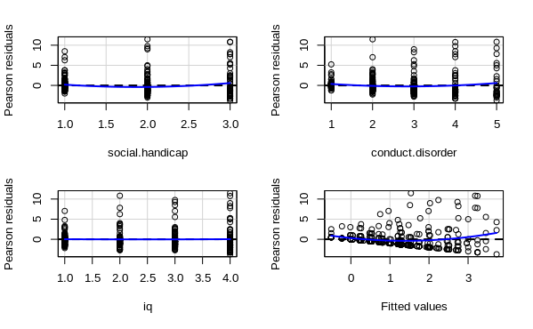

```r
residualPlots(model1)
```

## I already established that the dependent variable is non-normal, but this is confirmed by the residual plots. I will therefore attempt a boxTidwell transformation. I cannot attempt a boxCox because the dependent variable contains zeroes.

```r
boxTidwell(total_convictions ~ social.handicap + conduct.disorder + iq, data = cam.abbrev)
```

```
                 MLE of lambda Score Statistic (z) Pr(>|z|)
social.handicap         6.2160              3.0444 0.002331 **
conduct.disorder        3.5754              2.1295 0.033214 *
iq                      1.7732              0.2792 0.780115
---
Signif. codes:  0 ‘***’ 0.001 ‘**’ 0.01 ‘*’ 0.05 ‘.’ 0.1 ‘ ’ 1

iterations =  4
```

```r
tidwell.model <- lm(total_convictions ~ I(social.handicap^6.2) + I(conduct.disorder^3.6) + iq,
                             data = cam.abbrev)
summary(tidwell.model)
```

```
Call:
lm(formula = total_convictions ~ I(social.handicap^6.2) + I(conduct.disorder^3.6) +
    iq, data = cam.abbrev)

Residuals:
    Min      1Q  Median      3Q     Max
-4.9456 -0.9330 -0.3948  0.0670 11.9188

Coefficients:
                          Estimate Std. Error t value Pr(>|t|)
(Intercept)             -0.2340152  0.2752057  -0.850   0.3957
I(social.handicap^6.2)   0.0020447  0.0004076   5.017 8.27e-07 ***
I(conduct.disorder^3.6)  0.0068247  0.0013930   4.899 1.46e-06 ***
iq                       0.2705420  0.1100566   2.458   0.0144 *
---
Signif. codes:  0 ‘***’ 0.001 ‘**’ 0.01 ‘*’ 0.05 ‘.’ 0.1 ‘ ’ 1

Residual standard error: 2.214 on 360 degrees of freedom
Multiple R-squared:  0.1984,    Adjusted R-squared:  0.1917
F-statistic:  29.7 on 3 and 360 DF,  p-value: < 2.2e-16
```

```
                        Test stat Pr(>|Test stat|)
I(social.handicap^6.2)     0.0015          0.99879
I(conduct.disorder^3.6)   -0.1715          0.86395
iq                         0.3749          0.70793
Tukey test                 1.9321          0.05335 .
---
Signif. codes:  0 ‘***’ 0.001 ‘**’ 0.01 ‘*’ 0.05 ‘.’ 0.1 ‘ ’ 1
```

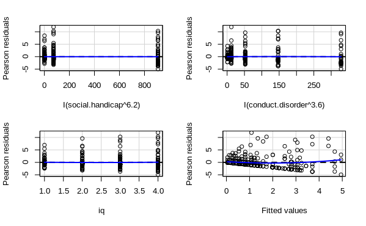

```r
residualPlots(tidwell.model)
```

## This does not seem to have made much difference, so I will retain model1 for the sake of simplicity. From this model, it appears that all variables are significant, social handicap to p < .001, conduct disorder to p < .001, and iq to p < .05. Social handicap is a composite of challenges a child could face and includes whether the family was being supported by social agencies, low income and socioeconmic status, poor or neglected housing conditions, large families, and physical neglect of the boy. Larger values suggest more hardship. This model indicates that more social handicap is associated with a greater number of convictions. Conduct disorder is a combined rating from the boys’ teachers and the interviewer; higher levels indicate worse ratings by bother teacher and interviewer. This model suggests that greater issues of conduct disorder at a young age are associated with more convictions. Lastly, a the IQ variable was coded such that a higher rating indicated a lower IQ. This model therefore indicates that a lower IQ is associated with more convictions. The model overall explains roughly 16.5% of the variance in the data.

## Just to confirm the results, I will run a similar model with the binary variable ever_convicted

```r
model2 <- glm(ever_convicted ~ social.handicap + conduct.disorder + iq, family = "binomial", data = cam.abbrev)
summary(model2)
```

```
Call:
glm(formula = ever_convicted ~ social.handicap + conduct.disorder +
    iq, family = "binomial", data = cam.abbrev)

Deviance Residuals:
    Min       1Q   Median       3Q      Max
-1.6430  -0.8887  -0.6744   1.0670   2.0648

Coefficients:
                 Estimate Std. Error z value Pr(>|z|)
(Intercept)       -3.0427     0.4262  -7.139 9.39e-13 ***
social.handicap    0.3767     0.1769   2.130  0.03318 *
conduct.disorder   0.3201     0.1097   2.918  0.00352 **
iq                 0.3404     0.1119   3.042  0.00235 **
---
Signif. codes:  0 ‘***’ 0.001 ‘**’ 0.01 ‘*’ 0.05 ‘.’ 0.1 ‘ ’ 1

(Dispersion parameter for binomial family taken to be 1)

    Null deviance: 461.51  on 363  degrees of freedom
Residual deviance: 422.53  on 360  degrees of freedom
AIC: 430.53

Number of Fisher Scoring iterations: 4
```

## githup repository: https://github.com/ascheunemann/Midterm.git